# REG ANN

```r
rm(list = ls(all = TRUE))
```

Loading packages

```r
library(dplyr)
#library(Hmisc)
library(cowplot)
library(WVPlots)
```

```r
library(neuralnet)
library(MASS)
library(ggplot2)
library(tidyverse)
library(GGally)
library(corrplot)
library(plyr)
library(boot)
```

database(Boston) : Cette base de données contient des informations collectées par le US Census Service concernant le logement dans la région de Boston Mass, Chargement de la base de données.

```r
data <- Boston
summary(data)
```

```
      crim                zn             indus            chas              nox
 Min.   : 0.00632   Min.   :  0.00   Min.   : 0.46   Min.   :0.00000   Min.   :0.3850
 1st Qu.: 0.08205   1st Qu.:  0.00   1st Qu.: 5.19   1st Qu.:0.00000   1st Qu.:0.4490
 Median : 0.25651   Median :  0.00   Median : 9.69   Median :0.00000   Median :0.5380
 Mean   : 3.61352   Mean   : 11.36   Mean   :11.14   Mean   :0.06917   Mean   :0.5547
 3rd Qu.: 3.67708   3rd Qu.: 12.50   3rd Qu.:18.10   3rd Qu.:0.00000   3rd Qu.:0.6240
 Max.   :88.97620   Max.   :100.00   Max.   :27.74   Max.   :1.00000   Max.   :0.8710
       rm             age              dis              rad              tax
 Min.   :3.561   Min.   :  2.90   Min.   : 1.130   Min.   : 1.000   Min.   :187.0
 1st Qu.:5.886   1st Qu.: 45.02   1st Qu.: 2.100   1st Qu.: 4.000   1st Qu.:279.0
 Median :6.208   Median : 77.50   Median : 3.207   Median : 5.000   Median :330.0
 Mean   :6.285   Mean   : 68.57   Mean   : 3.795   Mean   : 9.549   Mean   :408.2
 3rd Qu.:6.623   3rd Qu.: 94.08   3rd Qu.: 5.188   3rd Qu.:24.000   3rd Qu.:666.0
 Max.   :8.780   Max.   :100.00   Max.   :12.127   Max.   :24.000   Max.   :711.0
    ptratio          black            lstat            medv
 Min.   :12.60   Min.   :  0.32   Min.   : 1.73   Min.   : 5.00
 1st Qu.:17.40   1st Qu.:375.38   1st Qu.: 6.95   1st Qu.:17.02
 Median :19.05   Median :391.44   Median :11.36   Median :21.20
 Mean   :18.46   Mean   :356.67   Mean   :12.65   Mean   :22.53
 3rd Qu.:20.20   3rd Qu.:396.23   3rd Qu.:16.95   3rd Qu.:25.00
 Max.   :22.00   Max.   :396.90   Max.   :37.97   Max.   :50.00
```

```r
head(data)
```

|  | crim | zn | indus | chas | nox | rm | age | dis | rad | tax | ptratio | black | lstat | medv |
| --- | --- | --- | --- | --- | --- | --- | --- | --- | --- | --- | --- | --- | --- | --- |
| 1 | 0.00632 | 18 | 2.31 | 0 | 0.538 | 6.575 | 65.2 | 4.0900 | 1 | 296 | 15.3 | 396.90 | 4.98 | 24.0 |
| 2 | 0.02731 | 0 | 7.07 | 0 | 0.469 | 6.421 | 78.9 | 4.9671 | 2 | 242 | 17.8 | 396.90 | 9.14 | 21.6 |
| 3 | 0.02729 | 0 | 7.07 | 0 | 0.469 | 7.185 | 61.1 | 4.9671 | 2 | 242 | 17.8 | 392.83 | 4.03 | 34.7 |
| 4 | 0.03237 | 0 | 2.18 | 0 | 0.458 | 6.998 | 45.8 | 6.0622 | 3 | 222 | 18.7 | 394.63 | 2.94 | 33.4 |
| 5 | 0.06905 | 0 | 2.18 | 0 | 0.458 | 7.147 | 54.2 | 6.0622 | 3 | 222 | 18.7 | 396.90 | 5.33 | 36.2 |
| 6 | 0.02985 | 0 | 2.18 | 0 | 0.458 | 6.430 | 58.7 | 6.0622 | 3 | 222 | 18.7 | 394.12 | 5.21 | 28.7 |

Maintenant on va essayer de trouver les relation entre les variables (y ~ x) de la dataset en utilisant les fonction du package ggplot et corrplot

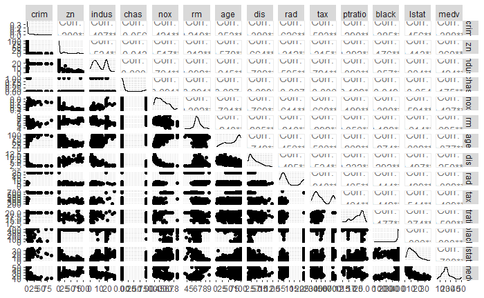

```r
ggpairs(data)
```

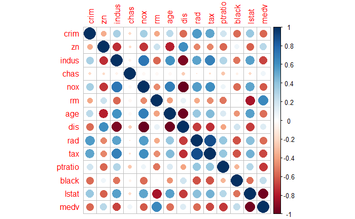

```r
corrplot(cor(data))
```

Fractionnement des données

```r
set.seed(12356)
index <- sample(1:nrow(data),round(0.75*nrow(data)))
train <- data[index,]
test <- data[-index,]
```

On va essayer dans un premier temps de créer un model de regression en utilisant la fonction glm

```r
Model.lm <- glm(medv~.,data = train)
summary(Model.lm)
```

```
Call:
glm(formula = medv ~ ., data = train)

Deviance Residuals:
     Min        1Q    Median        3Q       Max
-17.0238   -2.9690   -0.5031    1.6221   25.9157

Coefficients:
              Estimate Std. Error t value Pr(>|t|)
(Intercept)  32.832299   6.365333   5.158 4.10e-07 ***
crim         -0.071832   0.055245  -1.300  0.19434
zn            0.040867   0.016419   2.489  0.01325 *
indus         0.044350   0.068170   0.651  0.51572
chas          3.076135   1.081173   2.845  0.00469 **
nox         -16.058561   4.619845  -3.476  0.00057 ***
rm            3.997854   0.529169   7.555 3.39e-13 ***
age           0.004677   0.015724   0.297  0.76628
dis          -1.398006   0.239670  -5.833 1.20e-08 ***
rad           0.253069   0.079759   3.173  0.00164 **
tax          -0.010150   0.004267  -2.379  0.01789 *
ptratio      -0.917634   0.158458  -5.791 1.51e-08 ***
black         0.009189   0.003365   2.730  0.00663 **
lstat        -0.542371   0.062987  -8.611  < 2e-16 ***
---
Signif. codes:  0 ‘***’ 0.001 ‘**’ 0.01 ‘*’ 0.05 ‘.’ 0.1 ‘ ’ 1

(Dispersion parameter for gaussian family taken to be 23.83775)

    Null deviance: 31192.1  on 379  degrees of freedom
Residual deviance:  8724.6  on 366  degrees of freedom
AIC: 2299.2

Number of Fisher Scoring iterations: 2
```

Comme on voie dans le résumée la plupart des variables sont significative, on va après calculer L’accuracy du model après les prédictions

```r
Model.lm_pred <- predict(Model.lm,newdata = test)
MSE.lm <- (1/nrow(test))*sum((Model.lm_pred - test$medv)^2)
MSE.lm
```

```
[1] 19.83467
```

```r
print('Regression models MSE : ',MSE.lm)
```

```
[1] "Regression models MSE : "
```

~~~~~~~~Preparation du reseau de neuron::

Dans un premier temps, nous allons traiter les données, la y a plusieurs Methods permettant la normalisation de la base de données (z-normalisation/min-max), au cours de cette analyse on va essayer de normaliser les donnes dans l’intervalle [0,1]/[-1,1]. ce processus a généralement tendance à donner de meilleurs résultats

```r
MMnormal <- function(x){
  (x-min(x))/(max(x)-min(x))
}
scaled_data <- data %>% mutate_all(MMnormal)
head(scaled_data)
```

|  | crim | zn | indus | chas | nox | rm | age | dis | rad | tax | ptratio | black | lstat | medv |
| --- | --- | --- | --- | --- | --- | --- | --- | --- | --- | --- | --- | --- | --- | --- |
| 1 | 0.0000000000 | 0.18 | 0.06781525 | 0 | 0.3148148 | 0.5775053 | 0.6416066 | 0.2692031 | 0.00000000 | 0.20801527 | 0.2872340 | 1.0000000 | 0.08967991 | 0.4222222 |
| 2 | 0.0002359225 | 0.00 | 0.24230205 | 0 | 0.1728395 | 0.5479977 | 0.7826982 | 0.3489620 | 0.04347826 | 0.10496183 | 0.5531915 | 1.0000000 | 0.20447020 | 0.3688889 |
| 3 | 0.0002356977 | 0.00 | 0.24230205 | 0 | 0.1728395 | 0.6943859 | 0.5993821 | 0.3489620 | 0.04347826 | 0.10496183 | 0.5531915 | 0.9897373 | 0.06346578 | 0.6600000 |
| 4 | 0.0002927957 | 0.00 | 0.06304985 | 0 | 0.1502058 | 0.6585553 | 0.4418126 | 0.4485446 | 0.08695652 | 0.06679389 | 0.6489362 | 0.9942761 | 0.03338852 | 0.6311111 |
| 5 | 0.0007050701 | 0.00 | 0.06304985 | 0 | 0.1502058 | 0.6871048 | 0.5283213 | 0.4485446 | 0.08695652 | 0.06679389 | 0.6489362 | 1.0000000 | 0.09933775 | 0.6933333 |
| 6 | 0.0002644715 | 0.00 | 0.06304985 | 0 | 0.1502058 | 0.5497222 | 0.5746653 | 0.4485446 | 0.08695652 | 0.06679389 | 0.6489362 | 0.9929901 | 0.09602649 | 0.5266667 |

```r
train_ <- scaled_data[index,]
test_ <- scaled_data[-index,]
summary(test_)
```

```
      crim                 zn              indus              chas              nox
 Min.   :0.0000763   Min.   :0.00000   Min.   :0.02786   Min.   :0.00000   Min.   :0.03086
 1st Qu.:0.0008156   1st Qu.:0.00000   1st Qu.:0.17586   1st Qu.:0.00000   1st Qu.:0.13992
 Median :0.0032860   Median :0.00000   Median :0.33834   Median :0.00000   Median :0.31481
 Mean   :0.0566911   Mean   :0.12401   Mean   :0.39047   Mean   :0.09524   Mean   :0.36954
 3rd Qu.:0.0532961   3rd Qu.:0.09375   3rd Qu.:0.64663   3rd Qu.:0.00000   3rd Qu.:0.58848
 Max.   :1.0000000   Max.   :1.00000   Max.   :1.00000   Max.   :1.00000   Max.   :1.00000
       rm              age               dis               rad              tax
 Min.   :0.0000   Min.   :0.03193   Min.   :0.00441   Min.   :0.0000   Min.   :0.01145
 1st Qu.:0.4452   1st Qu.:0.43872   1st Qu.:0.07762   1st Qu.:0.1304   1st Qu.:0.18511
 Median :0.5103   Median :0.82286   Median :0.16747   Median :0.1739   Median :0.32634
 Mean   :0.5242   Mean   :0.68721   Mean   :0.23497   Mean   :0.3972   Mean   :0.44420
 3rd Qu.:0.5994   3rd Qu.:0.93718   3rd Qu.:0.31016   3rd Qu.:1.0000   3rd Qu.:0.91412
 Max.   :0.9895   Max.   :1.00000   Max.   :0.87122   Max.   :1.0000   Max.   :1.00000
    ptratio           black            lstat              medv
 Min.   :0.0000   Min.   :0.0000   Min.   :0.03173   Min.   :0.04444
 1st Qu.:0.5106   1st Qu.:0.9209   1st Qu.:0.13687   1st Qu.:0.23222
 Median :0.7021   Median :0.9858   Median :0.28394   Median :0.34222
 Mean   :0.6396   Mean   :0.8834   Mean   :0.29644   Mean   :0.37554
 3rd Qu.:0.8085   3rd Qu.:0.9982   3rd Qu.:0.42425   3rd Qu.:0.44000
 Max.   :1.0000   Max.   :1.0000   Max.   :0.83499   Max.   :1.00000
```

Avant d’établir le réseau il faut configure une paramètre très important qui est les couches cachée, généralement on n’a pas de Methods/règle spécifique pour faire ça mais c’est recommandé de choisir 3/2 nombre des inputs + nombre des neufs de l’output

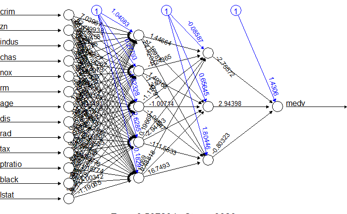

```r
names <- names(data)
formule = as.formula(paste("medv ~", paste(names[!names %in% "medv"], collapse = " + ")))
Model.RNN1 <- neuralnet(formule,train_,hidden = c(5,3),linear.output = TRUE)
plot(Model.RNN1)
```

Maintenant on peut prédire Medv du test puis calculer MSE (l’erreur quadratique moyen) Note : Pour calculer MSE il faut dénormaliser les données

```r
Model.RNN1_pred <- neuralnet::compute(Model.RNN1,test_[1:13])
Model.RNN1_pred_den <- Model.RNN1_pred$net.result*(max(data$medv)-min(data$medv))+min(data$medv)
test_den <- (test_$medv)*(max(data$medv)-min(data$medv))+min(data$medv)
MSE.RNN1 <- sum((Model.RNN1_pred_den - test_den)^2)/nrow(test_)
paste("MSE pour Model de regression : ",MSE.lm)
```

```
[1] "MSE pour Model de regression :  19.8346709881378"
```

```r
paste("MSE pour Reseau de neuron : ",MSE.RNN1)
```

```
[1] "MSE pour Reseau de neuron :  12.4251121887725"
```

```r
#Erreur liee a l'entrainement
Train_MSE.RNN1 <- sum((Model.RNN1$net.result[[1]] - train_[,14])^2)/nrow(train_)
#Erreur liee au test
Test_MSE.RNN1 <- sum((Model.RNN1_pred$net.result - test_[,14])^2)/nrow(test_)
Train_MSE.RNN1
```

```
[1] 0.002669967
```

```r
Test_MSE.RNN1
```

```
[1] 0.006135858
```

Comme on voie dans Les résultats Le réseau fait un meilleur travail que le modèle linéaire pour prédire medv mais ce n’est pas diffusant pour juger alors par la suite on va performer une cross validation (a la fin). On va visualiser les résultats dans un scatter-plot

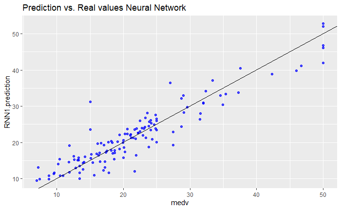

```r
#par(mfrow=c(1,2))
x <- test$RNN1.prediction <- Model.RNN1_pred_den
ggplot(test, aes(y = RNN1.prediction, x = medv)) +
  geom_point(color = "blue", alpha = 0.7) +
  geom_abline(color = "black") +
  ggtitle("Prediction vs. Real values Neural Network")
```

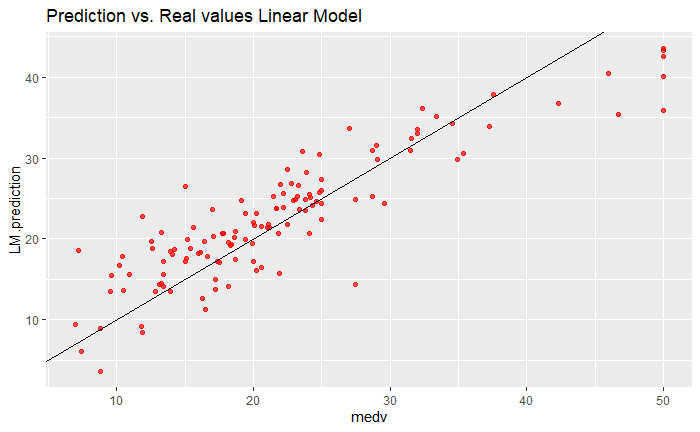

```r
  #gglegend("NN")
y <- test$LM.prediction <- Model.lm_pred
ggplot(test, aes(y = LM.prediction, x = medv)) +
  geom_point(color = "red", alpha = 0.7) +
  geom_abline(color = "black") +
  ggtitle("Prediction vs. Real values Linear Model")
```

```r
  #gglegend("GLM")
x
```

[output not shown]

[output cut: 112 more lines]

```r
y
```

[output not shown]

Comme on voie dans les graphs, les point dans le réseau sont plus concentrer autour du ligne de régression!

~~~~~Amelioration du reseau ::

Le Réseau de neurone est une boîte noire alors que la seule méthode pour enrichir le model et d’essayer plusieurs fois et de changer les paramètres : hidden/act.fct ..

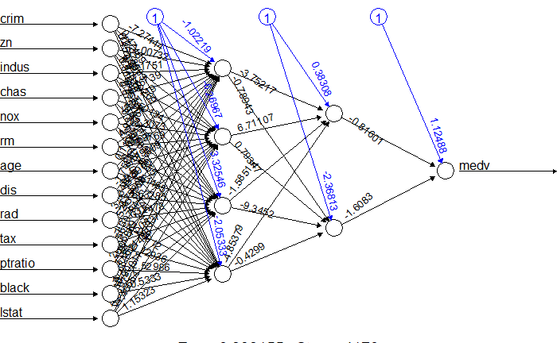

```r
Model.RNN2 <- neuralnet(formule,train_,hidden = c(4,2),act.fct = "logistic",linear.output = TRUE)
plot(Model.RNN2)
```

Testing the Model

```r
Model.RNN2_pred <- neuralnet::compute(Model.RNN2,test_[,-14])
#Erreur liee a l'entrainement
Train_MSE.RNN2 <- sum((Model.RNN2$net.result[[1]] - train_[,14])^2)/nrow(train_)
#Erreur liee au test
Test_MSE.RNN2 <- sum((Model.RNN2_pred$net.result - test_[,14])^2)/nrow(test_)
paste("Erreur liee au train : ",Train_MSE.RNN2)
```

```
[1] "Erreur liee au train :  0.00206923662666092"
```

```r
paste("Erreur liee au test : ",Test_MSE.RNN2)
```

```
[1] "Erreur liee au test :  0.00464100411534792"
```

On va maintenant essayer la fonction d’activation tangent hyperbolique, pour cela on est besoin de réajuster notre intervalle vers [-1,1]

```r
set.seed(1256)
norm_tanh <- function(x){
   (2 * ((x - min(x))/(max(x) - min(x)))) - 1
}
train_tanh <- train_ %>% mutate_all(norm_tanh)
test_tanh <- test_ %>% mutate_all(norm_tanh)
Model.RNN3 <- neuralnet(formule,train_tanh,hidden = c(5,3),act.fct = "tanh",linear.output = TRUE)
#model prediction
Model.RNN3_pred <- neuralnet::compute(Model.RNN3,test_tanh[,-14])
#Erreur liee a l'entrainement
Train_MSE.RNN3 <- sum((Model.RNN3$net.result[[1]] - train_tanh[,14])^2)/nrow(train_tanh)
#Erreur liee au test
Test_MSE.RNN3 <- sum((Model.RNN3_pred$net.result - test_tanh[,14])^2)/nrow(test_tanh)
paste("Erreur liee au train : ",Train_MSE.RNN3)
```

```
[1] "Erreur liee au train :  0.00980645769627724"
```

```r
paste("Erreur liee au test : ",Test_MSE.RNN3)
```

```
[1] "Erreur liee au test :  0.609015512448798"
```

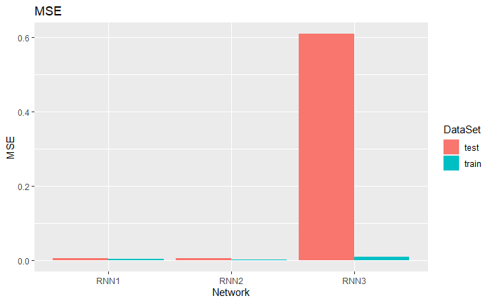

```r
RNN_Errors <- tibble(Network = rep(c("RNN1", "RNN2", "RNN3"), each = 2),
                               DataSet = rep(c("train", "test"), time = 3),
                               MSE = c(Train_MSE.RNN1, Test_MSE.RNN1,
                                       Train_MSE.RNN2, Test_MSE.RNN2,
                                       Train_MSE.RNN3, Test_MSE.RNN3))

RNN_Errors %>%
  ggplot(aes(Network, MSE, fill = DataSet)) +
  geom_col(position = "dodge") +
  ggtitle("MSE")
```

Selon le graph on note RNN1 et RNN2 sont meilleur que RNN3, on va choisir RNN2

Généralement c’est recommander de construire Le réseau plusieurs fois et puis choisir le meilleur ::

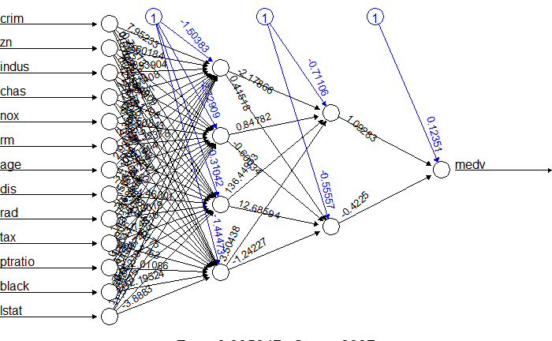

```r
Model.RNN2 <- neuralnet(formule,train_,hidden = c(4,2),act.fct = "logistic",linear.output = TRUE,rep = 10)
plot(Model.RNN2,rep = "best")
```

~~~~~~~~Cross validation

Cross validation est une autre étape très importante de la construction de modèles prédictifs, cette Methods nous permet de répéter les processus qu’on a déjà fait :

–> Cross validation pour le model de régression par glm

```r
set.seed(1256)
fit.lm <- glm(medv~.,data=data)
fit.lm_cv <- cv.glm(data,fit.lm,K=10)
```

```r
paste("Raw Cross error : ",fit.lm_cv$delta[1],"||| Adjusted : ",fit.lm_cv$delta[2])
```

```
[1] "Raw Cross error :  23.5436971751115 ||| Adjusted :  23.4545702309646"
```

```r
set.seed(450)
cv.error <- NULL
k <- 10
pbar <- create_progress_bar('text')
pbar$init(k)
for(i in 1:k){
    index <- sample(1:nrow(data),round(0.9*nrow(data)))
    train.cv <- scaled_data[index,]
    test.cv <- scaled_data[-index,]
    nn <- neuralnet(formule,data=train.cv,hidden=c(4,2),linear.output=T)
    pr.nn <- compute(nn,test.cv[,1:13])
    pr.nn <- pr.nn$net.result*(max(data$medv)-min(data$medv))+min(data$medv)
    test.cv.r <- (test.cv$medv)*(max(data$medv)-min(data$medv))+min(data$medv)
    cv.error[i] <- sum((test.cv.r - pr.nn)^2)/nrow(test.cv)
    pbar$step()
}
```

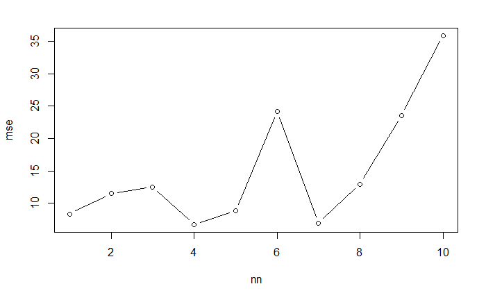

```r
plot(cv.error,type = "b",xlab = "nn",ylab = "mse")
```

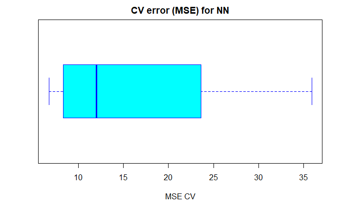

```r
boxplot(cv.error,xlab='MSE CV',col='cyan',
        border='blue',names='CV error (MSE)',
        main='CV error (MSE) for NN',horizontal=TRUE)
```

```r
library(caret)
index <- sample(1:nrow(data),round(0.9*nrow(data)))
train.cv <- data[index,]
model.nnet = train(medv~., data=train.cv,
method="nnet",
preProc=c("center", "scale"))
```

```
There were missing values in resampled performance measures.
```

```r
print(model.nnet)
```

```
Neural Network

455 samples
 13 predictor

Pre-processing: centered (13), scaled (13)
Resampling: Bootstrapped (25 reps)
Summary of sample sizes: 455, 455, 455, 455, 455, 455, ...
Resampling results across tuning parameters:

  size  decay  RMSE      Rsquared    MAE
  1     0e+00  23.43834         NaN  21.59211
  1     1e-04  23.43834  0.24590056  21.59211
  1     1e-01  23.43839  0.57233149  21.59217
  3     0e+00  23.43834         NaN  21.59211
  3     1e-04  23.43834  0.12409658  21.59211
  3     1e-01  23.43837  0.57716261  21.59215
  5     0e+00  23.43834         NaN  21.59211
  5     1e-04  23.43834  0.02364894  21.59211
  5     1e-01  23.43837  0.55953341  21.59215

RMSE was used to select the optimal model using the smallest value.
The final values used for the model were size = 1 and decay = 0.
```